# Final AB Testing slides

## Analyze A/B Test Results

- Introduction
- Part I - Probability
- Part II - A/B Test
- Part III - Regression
- Part IV - Give It More Time Or Not
- Part V - Final Conclusion

### Introduction

For this project, I will be working to understand the results of an A/B test run by an e-commerce website. The goal is to work through this notebook to help the company understand if they should implement the new page, keep the old page, or perhaps run the experiment longer to make their decision.

### Part I - Probability

d. The proportion of users converted.

```python
len(df.query('converted==1').user_id.unique()) / len(df.user_id.unique())
```

```
0.12104245244060237
```

`2.` For the rows where **treatment** does not match with **new_page** or **control** does not match with **old_page**, we cannot be sure if this row truly received the new or old page so we will remove those rows.

```python
df2 = df.query('(group=="treatment" and landing_page =="new_page") or (group=="control" and landing_page=="old_page")')
```

a. What is the probability of an individual converting regardless of the page they receive?

```python
df2.converted.mean()
```

```
0.11959708724499628
```

b. Given that an individual was in the `control` group, what is the probability they converted?

```python
control_group_proportion = df2[df2['group'] == "control"]['converted'].mean()
control_group_proportion
```

```
0.1203863045004612
```

c. Given that an individual was in the `treatment` group, what is the probability they converted?

```python
treat_group_proportion = df2[df2['group'] == "treatment"]['converted'].mean()
treat_group_proportion
```

```
0.11880806551510564
```

```python
treat_group_proportion - control_group_proportion
```

```
-0.0015782389853555567
```

d. What is the probability that an individual received the new page?

```python
df2.query('landing_page=="new_page"').user_id.count() / df2.user_id.count()
```

```
0.50006194422266881
```

**it seems that there is no sufficient evidence to conclude that the new treatment page leads to more conversions since the probability is 0.11**

### Part II - A/B Test

Notice that because of the time stamp associated with each event, you could technically run a hypothesis test continuously as each observation was observed.

However, then the hard question is do you stop as soon as one page is considered significantly better than another or does it need to happen consistently for a certain amount of time? How long do you run to render a decision that neither page is better than another?

These questions are the difficult parts associated with A/B tests in general.

`1.` For now, consider you need to make the decision just based on all the data provided. If you want to assume that the old page is better unless the new page proves to be definitely better at a Type I error rate of 5%, what should your null and alternative hypotheses be? You can state your hypothesis in terms of words or in terms of **$p_{old}$** and **$p_{new}$**, which are the converted rates for the old and new pages.

The null hypthoesis: the old page is better than or equal to the new page (p_new - p_old <= 0)  
The alternative hypthoesis: the new page is better than the old page (p_new - p_old > 0) .

`2.` Assume under the null hypothesis, $p_{new}$ and $p_{old}$ both have "true" success rates equal to the **converted** success rate of the old page - that is $p_{new}$ and $p_{old}$ are equal. Furthermore, assume they are equal to the **converted** rate in **ab_data.csv** of the old page.

Using a sample size for each page equal to the ones in **ab_data.csv**.

Performing the sampling distribution for the difference in **converted** between the two pages over 10,000 iterations of calculating an estimate from the null.

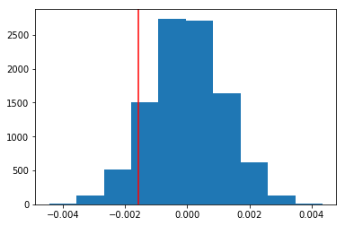

```python
plt.axvline(treat_group_proportion - control_group_proportion, color='r')
plt.hist(p_diff);
```

j. What proportion of the **p_diffs** are greater than the actual difference observed in **ab_data.csv**?

```python
(p_diff >= (treat_group_proportion - control_group_proportion)).mean()
```

```
0.90669999999999995
```

**P-value = 0.90 which means that we can not reject the null hypthoessis and the convert of the old page is greater**

m. Now use `stats.proportions_ztest` to compute your test statistic and p-value. [Here](http://knowledgetack.com/python/statsmodels/proportions_ztest/) is a helpful link on using the built in.

```python
# resource: https://sonalake.com/latest/hypothesis-testing-of-proportion-based-samples/
from statsmodels.stats.proportion import proportions_ztest
import numpy as np

sample_success_a, sample_size_a = (s_old, n_old)
sample_success_b, sample_size_b = (s_new, n_new)
successes = np.array([sample_success_a, sample_success_b])
samples = np.array([sample_size_a, sample_size_b])
stat, p_value = proportions_ztest(count=successes, nobs=samples, alternative="smaller")
# report
print('z_stat: %0.3f, p_value: %0.3f' % (stat, p_value))
```

```
z_stat: 1.311, p_value: 0.905
```

### Part III - A regression approach

`1.` In this final part, you will see that the result I achieved in the A/B test in Part II above can also be achieved by performing regression.

a. Since each row is either a conversion or no conversion, what type of regression should I be performing in this case?

**Logistic Regression**

```python
result.summary2()
```

| Model: | Logit | No. Iterations: | 6.0000 |
| --- | --- | --- | --- |
| Dependent Variable: | converted | Pseudo R-squared: | 0.000 |
| Date: | 2020-09-30 06:52 | AIC: | 212780.3502 |
| No. Observations: | 290584 | BIC: | 212801.5095 |
| Df Model: | 1 | Log-Likelihood: | -1.0639e+05 |
| Df Residuals: | 290582 | LL-Null: | -1.0639e+05 |
| Converged: | 1.0000 | Scale: | 1.0000 |

|  | Coef. | Std.Err. | z | P>\|z\| | [0.025 | 0.975] |
| --- | --- | --- | --- | --- | --- | --- |
| intercept | -1.9888 | 0.0081 | -246.6690 | 0.0000 | -2.0046 | -1.9730 |
| ab_page | -0.0150 | 0.0114 | -1.3109 | 0.1899 | -0.0374 | 0.0074 |

e. What is the p-value associated with **ab_page**? Why does it differ from the value you found in **Part II**

##### P value = 0.189 it different because it is two tails

##### We Can consider one tail here by dividing p-value by 2 if we do this we are still faill to reject the null because it will be equal to 1 - 0.188/ 2) = 0.90

**Hint**: What are the null and alternative hypotheses associated with your regression model, and how do they compare to the null and alternative hypotheses in **Part II**?

The null in regression model says that there is no difference betweeen two proportion: P_new - P_old = 0  
The Alternative in regression model syas that there is a difference between two proportion: p_new - P_old != 0  
so this is a two tails test compared two one tail test in part II which is one tail test, and we can compare each other by  
diving the resualt of P_value in two tails test by 2

**using landing page as the only feature on our model makes the model dependent only on the proportion of `converted` which was not important enough to build a model after geting the proportion and p-value from previous part using A/B testing and when adding more factors this will make us individualize predictions**

```python
joined_df[['CA', 'UK', 'US']] = pd.get_dummies(joined_df['country']) # convert categorical varibles to zeros and ones
model = sm.Logit(joined_df['converted'], joined_df[['intercept' ,'CA', 'UK']])
result = model.fit() # finting the model
result.summary2() # showing the result
```

```
Optimization terminated successfully.
         Current function value: 0.366116
         Iterations 6
```

| Model: | Logit | No. Iterations: | 6.0000 |
| --- | --- | --- | --- |
| Dependent Variable: | converted | Pseudo R-squared: | 0.000 |
| Date: | 2020-09-30 06:52 | AIC: | 212780.8333 |
| No. Observations: | 290584 | BIC: | 212812.5723 |
| Df Model: | 2 | Log-Likelihood: | -1.0639e+05 |
| Df Residuals: | 290581 | LL-Null: | -1.0639e+05 |
| Converged: | 1.0000 | Scale: | 1.0000 |

|  | Coef. | Std.Err. | z | P>\|z\| | [0.025 | 0.975] |
| --- | --- | --- | --- | --- | --- | --- |
| intercept | -1.9967 | 0.0068 | -292.3145 | 0.0000 | -2.0101 | -1.9833 |
| CA | -0.0408 | 0.0269 | -1.5178 | 0.1291 | -0.0935 | 0.0119 |
| UK | 0.0099 | 0.0133 | 0.7458 | 0.4558 | -0.0161 | 0.0360 |

- As we see here from p-values of CA and UK there is no significant that the country has effect on conversion rate.

```python
joined_df[['CA', 'UK', 'US']] = pd.get_dummies(joined_df['country']) # convert categorical varibles to zeros and ones
joined_df['ab_CA'] = joined_df['ab_page'] * joined_df['CA']
joined_df['ab_UK'] = joined_df['ab_page'] * joined_df['UK']
model = sm.Logit(joined_df['converted'], joined_df[['intercept', 'ab_page' ,'CA', 'UK', 'ab_CA', 'ab_UK']]) # most valuable columns
result = model.fit() # finting the model
result.summary2() # showing the result
```

```
Optimization terminated successfully.
         Current function value: 0.366109
         Iterations 6
```

| Model: | Logit | No. Iterations: | 6.0000 |
| --- | --- | --- | --- |
| Dependent Variable: | converted | Pseudo R-squared: | 0.000 |
| Date: | 2020-09-30 06:52 | AIC: | 212782.6602 |
| No. Observations: | 290584 | BIC: | 212846.1381 |
| Df Model: | 5 | Log-Likelihood: | -1.0639e+05 |
| Df Residuals: | 290578 | LL-Null: | -1.0639e+05 |
| Converged: | 1.0000 | Scale: | 1.0000 |

|  | Coef. | Std.Err. | z | P>\|z\| | [0.025 | 0.975] |
| --- | --- | --- | --- | --- | --- | --- |
| intercept | -1.9865 | 0.0096 | -206.3440 | 0.0000 | -2.0053 | -1.9676 |
| ab_page | -0.0206 | 0.0137 | -1.5052 | 0.1323 | -0.0473 | 0.0062 |
| CA | -0.0175 | 0.0377 | -0.4652 | 0.6418 | -0.0914 | 0.0563 |
| UK | -0.0057 | 0.0188 | -0.3057 | 0.7598 | -0.0426 | 0.0311 |
| ab_CA | -0.0469 | 0.0538 | -0.8718 | 0.3833 | -0.1523 | 0.0585 |
| ab_UK | 0.0314 | 0.0266 | 1.1807 | 0.2377 | -0.0207 | 0.0835 |

### Part IV - Give It More Time Or Not

#### Now I'm trying to see if it good to give the test more time or that is enough

- I will do this by trying to do Hypothesis testing for each day cumulative and not cumulative and see their p-values over time.

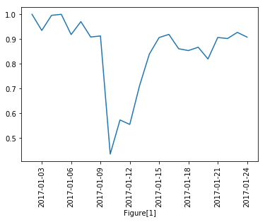

```python
# here we drawing the p-values to see the trend
#fig = plt.figure(figsize=(20,20));
plt.plot(od.keys(), od.values());
plt.xlabel("Figure[1]")
plt.xticks(rotation=90);
```

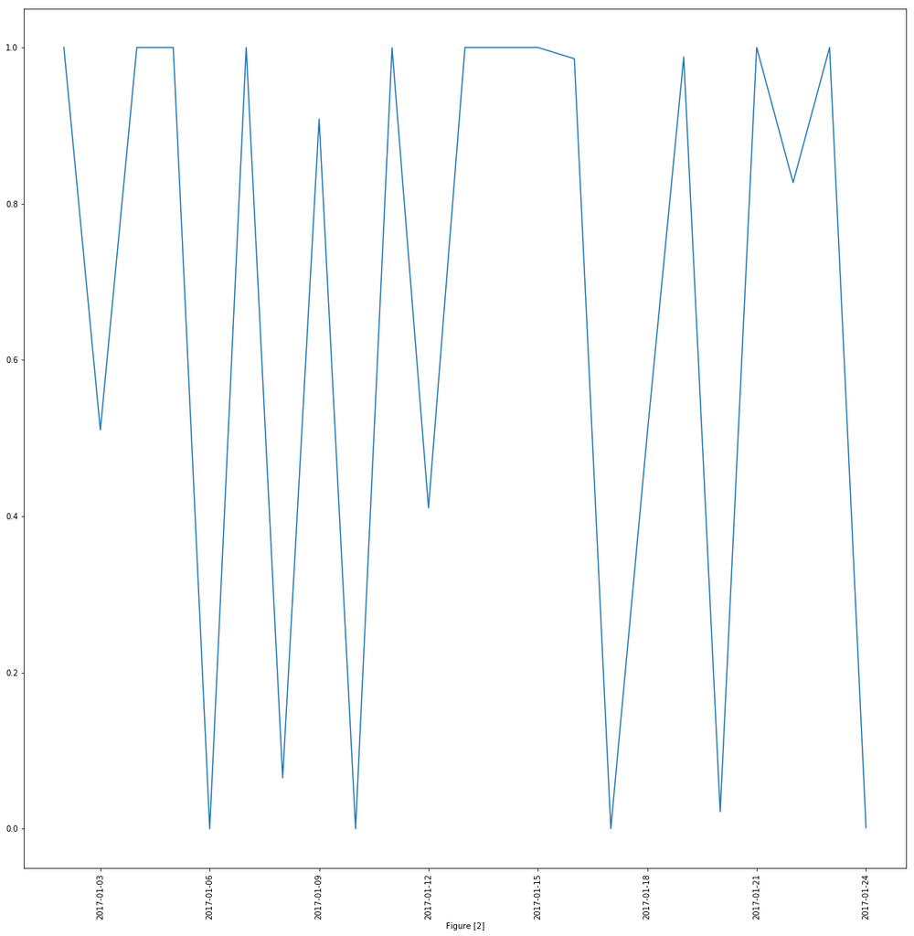

```python
# here we drawing the p-values to see the trend.
fig = plt.figure(figsize=(20,20));
plt.plot(od.keys(), od.values());
plt.xlabel("Figure [2]")
plt.xticks(rotation=90);
```

## Final Conclusion

### Part I - Probability:

- the proportion of people who get the new page almost the same as to the people who get the old page.
- the conversion rate is week regardless to the page. ### Part II- A/B Test
- The old page is better than the new page but there is comming suggestion.

### Part III - A regression approach

- The country that the user came from does not influence the conversion rate.
- The page type by each country does not influecne the conversion rate.

### Part IV - Give It More Time Or Not

- I strongly suggest to give the test more time to make sure that by the time there will be no change in favour of new page because there is no trend in shows that it goes down or up and if users are not unique users this may cause change aversion or novelty effect  
  Novelty effect: https://en.wikipedia.org/wiki/Novelty_effect.  
  Change Aversion: https://en.wiktionary.org/wiki/change_aversion
- If the company can't give the test more time for some reasons then the resualt is that the old page is better or the same as the new page.

```python
!jupyter nbconvert "Final AB Testing".ipynb --to slides --post serve
```